# Size-Based Indicator Analysis

Kevin M. Purcell

Tuesday, November 18, 2014

| Parameter | Description |
| --- | --- |
| GLFID | unique integer (int) entry id |
| CRUISEID | unique int for ea. entry in CRUSIES table |
| BGSID | Unique int for ea. entry in BGSREC table |
| STATIONID | unique int for ea. entry in STAREC table |
| VESSEL | unique int for ea. entry in VESSELS table |
| CRUISE_NO | four character (ch.) string format YYXX |
| P_STA_NO | five ch. string for Pascagoula Station No. |
| BIO_CODE | 9 digit field for Genus species biocode |
| NODC_GLF | no current used |
| GENUS_GLF | 7 ch. field for Genus |
| SPEC_GLF | 6 ch. field for species |
| INDVL_WT | 4 digit XXX.X field for weight (kg) |
| MEASCD_GLF | 2 ch. field containing measurement code |
| LEN_GLF | 4 ch. field (numeric) of length (mm) |
| SEX_GLF | 1 ch. field representing sex (M, F, U) can be blank |
| MAT_GLF | 1 ch. field representing maturity code |
| meas_typ | unique integer (int) entry id |

|  | Code | Genus species | Common name |
| --- | --- | --- | --- |
| 1 | 330234402 | AMUSIUM PAPYRACEUM | paper scallop |
| 2 | 121060101 | ANCHOA HEPSETUS | broad-striped anchovy |
| 3 | 121060103 | ANCHOA MITCHILLI | bay anchovy |
| 4 | 141020101 | ARIUS FELIS | hardhead catfish |
| 5 | 121050302 | BREVOORTIA PATRONUS | Gulf menhaden |
| 6 | 229260105 | CALAPPA SULCATA | yellow box crab |
| 7 | 229110203 | CALLINECTES SAPIDUS | blue crab |
| 8 | 229110206 | CALLINECTES SIMILIS | lesser blue crab |
| 9 | 170110803 | CARANX CRYSOS | blue runner |
| 10 | 170024805 | CENTROPRISTIS PHILADELPHICUS | Rock Sea bass |
| 11 | 170110902 | CHLOROSCOMBRUS CHRYSURUS | Atlantic bumper |
| 12 | 170200900 | CYNOSCION | sea trout |
| 13 | 170200901 | CYNOSCION ARENARIUS | sand seatrout |
| 14 | 170200904 | CYNOSCION NOTHUS | silver seatrout |
| 15 | 170020905 | DIPLECTRUM BIVITTATUM | dwarf sand perch |
| 16 | 183010602 | ETROPUS CROSSOTUS | fringed flounder |
| 17 | 121051602 | ETRUMEUS TERES | Atlantic red herring |
| 18 | 195050401 | HALIEUTICHTHYS ACULEATUS | pancake batfish |
| 19 | 121052004 | HARENGULA JAGUANA | scaled herring |
| 20 | 170211601 | LAGODON RHOMBOIDES | pinfish |
| 21 | 170201604 | LARIMUS FASCIATUS | banded drum |
| 22 | 170201701 | LEIOSTOMUS XANTHURUS | spot |
| 23 | 171010202 | LEPOPHIDIUM BREVIBARBE | blackedge cusk-eel |
| 24 | 347020200 | LOLIGO |  |
| 25 | 347020201 | LOLIGO PEALEII | longfin inshore squid |
| 26 | 347020202 | LOLIGO PLEII | Slender Inshore squid |
| 27 | 347020101 | LOLLIGUNCULA BREVIS | Atlantic brief squid |
| 28 | 170151107 | LUTJANUS CAMPECHANUS | red snapper |
| 29 | 170201902 | MICROPOGONIAS UNDULATUS | Atlantic croaker |
| 30 | 228010701 | PENAEUS AZTECUS | brown shrimp |
| 31 | 228010703 | PENAEUS DUORARUM | northern pink shrimp |
| 32 | 228010705 | PENAEUS SETIFERUS | northern white shrimp |
| 33 | 170511103 | PEPRILUS BURTI | Gulf butterfish |
| 34 | 170203101 | POGONIAS CROMIS | black drum |
| 35 | 166010401 | POLYDACTYLUS OCTONEMUS | Atlantic threadfin |
| 36 | 229110803 | PORTUNUS GIBBESII | iridescent swimming crab |
| 37 | 229110808 | PORTUNUS SPINICARPUS | longspine swimming crab |
| 38 | 168020519 | PRIONOTUS LONGISPINOSUS | bigeye searobin |
| 39 | 168020513 | PRIONOTUS PARALATUS | Mexican searobin |
| 40 | 168020523 | PRIONOTUS STEARNSI | shortwing searobin |
| 41 | 170151802 | PRISTIPOMOIDES AQUILONARIS | wenchman |
| 42 | 110120101 | RHINOPTERA BONASUS | cownose ray |
| 43 | 108021802 | RHIZOPRIONODON TERRAENOVAE | Atlantic sharpnose shark |
| 44 | 129040201 | SAURIDA BRASILIENSIS | largescale lizardfish |
| 45 | 170440803 | SCOMBEROMORUS MACULATUS | Atlantic Spanish mackerel |
| 46 | 170024202 | SERRANUS ATROBRANCHUS | blackear bass |
| 47 | 228320101 | SICYONIA BREVIROSTRIS | brown rock shrimp |
| 48 | 228320102 | SICYONIA DORSALIS | lesser rock shrimp |
| 49 | 228300400 | SOLENOCERA |  |
| 50 | 189080611 | SPHOEROIDES PARVUS | least puffer |
| 51 | 108040104 | SPHYRNA TIBURO | bonnethead |
| 52 | 225010100 | SQUILLA |  |
| 53 | 225010103 | SQUILLA EMPUSA | Mantis shrimp |
| 54 | 148041501 | STEINDACHNERIA ARGENTEA | luminous hake |
| 55 | 170203902 | STELLIFER LANCEOLATUS | star drum |
| 56 | 170213403 | STENOTOMUS CAPRINUS | longspine porgy |
| 57 | 183011001 | SYACIUM GUNTERI | shoal flounder |
| 58 | 183011003 | SYACIUM PAPILLOSUM | dusky flounder |
| 59 | 129040302 | SYNODUS FOETENS | inshore lizardfish |
| 60 | 170113802 | TRACHURUS LATHAMI | rough scad |
| 61 | 228011800 | TRACHYPENEUS |  |
| 62 | 228011801 | TRACHYPENEUS CONSTRICTUS |  |
| 63 | 228011802 | TRACHYPENEUS SIMILIS | Roughback shrimp |
| 64 | 170460402 | TRICHIURUS LEPTURUS | Atlantic cutlassfish |
| 65 | 170220605 | UPENEUS PARVUS | dwarf goatfish |

```
## [1] "BIO_CODE"    "common_name" "bycatch"
```

```
##   BGSID CRUISEID STATIONID VESSEL CRUISE_NO P_STA_NO CATEGORY GENUS_BGS
## 1     1      581         4      4       256        4        3   RHIZOPR
## 2     2      581         4      4       256        4        3   SPHYRNA
## 3     3      581         4      4       256        4        3   HARENGU
## 4     4      581         4      4       256        4        3   OPISTHO
## 5     5      581         4      4       256        4        3   SARDINE
## 6     6      581         4      4       256        4        3    ANCHOA
##   SPEC_BGS BGSCODE CNT CNTEXP SAMPLE_BGS SELECT_BGS   BIO_BGS NODC_BGS
## 1   TERRAE           1      1      0.000      0.716 108021802        0
## 2   TIBURO           5      5      0.000      0.959 108040104        0
## 3   JAGUAN           9     91      0.155      1.559 121052004        0
## 4   OGLINU           2     20      0.049      0.493 121053002        0
## 5   AURITA           1     10      0.021      0.211 121053801        0
## 6   HEPSET           4     40      0.058      0.583 121060101        0
##   IS_SAMPLE TAXONID
## 1         N      NA
## 2         N      NA
## 3         Y      NA
## 4         Y      NA
## 5         Y      NA
## 6         Y      NA
```

```
##   GLFID CRUISEID BGSID STATIONID VESSEL CRUISE_NO P_STA_NO  BIO_CODE
## 1     1      581     1         4      4       256        4 108021802
## 2     2      581     2         4      4       256        4 108040104
## 3     3      581     2         4      4       256        4 108040104
## 4     4      581     2         4      4       256        4 108040104
## 5     5      581     2         4      4       256        4 108040104
## 6     6      581     2         4      4       256        4 108040104
##   NODC_GLF GENUS_GLF SPEC_GLF INDVL_WT MEASCD_GLF LEN_GLF SEX_GLF MAT_GLF
## 1        0   RHIZOPR   TERRAE       NA         18     526       F       1
## 2        0   SPHYRNA   TIBURO       NA         18     356       M       1
## 3        0   SPHYRNA   TIBURO       NA         18     378              NA
## 4        0   SPHYRNA   TIBURO       NA         18     347              NA
## 5        0   SPHYRNA   TIBURO       NA         18     360              NA
## 6        0   SPHYRNA   TIBURO       NA         18     384              NA
##   meas_typ
## 1       TL
## 2       TL
## 3       TL
## 4       TL
## 5       TL
## 6       TL
```

## Objectives

Identify and calculate size-based indicator (SBI) time series for the Gulf of Mexico based on the length-frequency data collected by SEAMAP for our focal species. Indicatory identification is derived from two primary sources [Shin et al. 2005](http://icesjms.oxfordjournals.org/content/62/3/384) and [Rochet and Trinkle 2003](http://www.nrcresearchpress.com/doi/abs/10.1139/f02-164). Initially a global time series will be developed for community-wide metrics of mean length:

$\bar{L}=\frac{(L_{1}A_{1}) + (L_{2}A_{2}) + \cdots + (L_{N}A_{N})}{A_{1} + A_{2} + \cdots + A_{N}}$

## Methods

To evaluate temporal patterns in the mean length of the community we evaluated an overall time-series for all 65 taxonomic entities involved in our study, as well as time-series for our four bycatch categories (Catch, High, Rare, Never). All calculations were conducted on post-1987 data due to previously stated inconsistencies in sampling protocols, and only measurements in which total length (TL) were preformed (55.5% of observations).

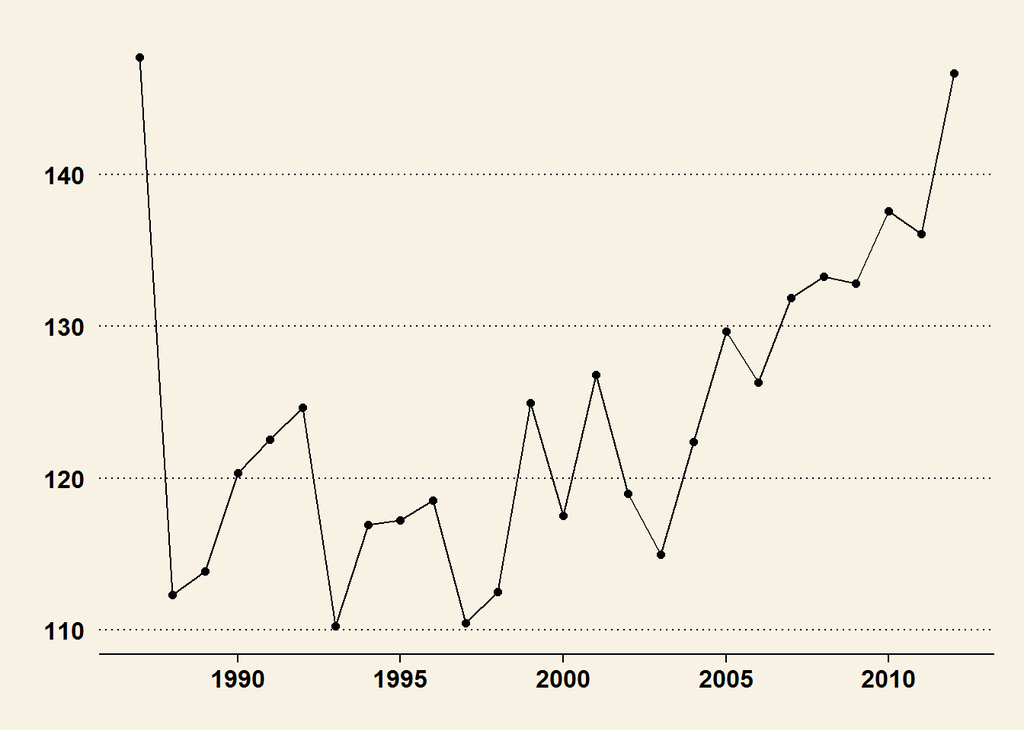

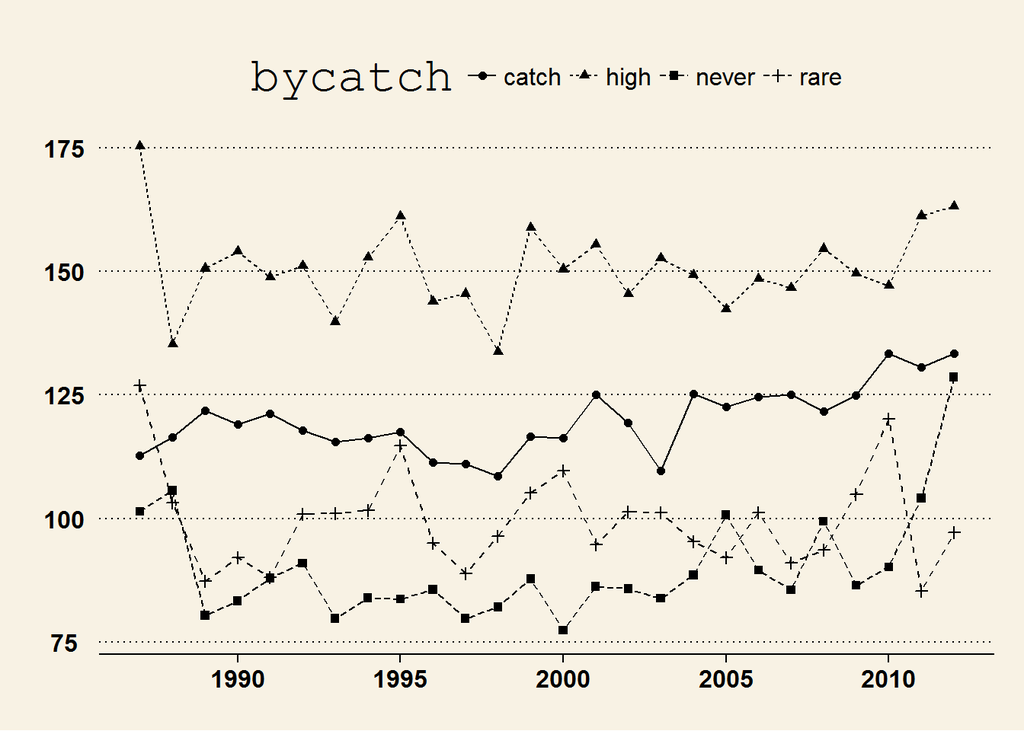